# GWAS Meta analysis Using GXwasR

By Banabithi Bose, Northwestern University

1/13/2024

## Meta analysis using GXwasR

Here we will present a tutorial showing how to perform meta analysis utilizing the R package GXwasR.

The example data sets for performing the tutorial can be accssed from “data” folder of the package.

## Example Datasets

Example datasets are provided with the package and can be accessed by calling data(“GXwasRData”).

Load the example datasets to perform this tutorial.

```r
## Load library
library(GXwasR)
data("GXwasRData")
```

1. Two sets of summary GWAS summary statistics in .Rda files will be required to perform this tutorial. **Summary_Stat_Ex1.Rda** **Summary_Stat_Ex2.Rda**

Check one of the summary statistics data

```r
## Visualize three rows and all the columns
Summary_Stat_Ex1[1:3,]
```

```
##   CHR         SNP     BP A1 TEST NMISS    BETA     SE     L95   U95    STAT
## 1   1 rs143773730  73841  T  ADD   125 -0.0789 0.2643 -0.5968 0.439 -0.2986
## 4   1 rs147281566 775125  T  ADD   125 -0.3959 1.2380 -2.8230 2.031 -0.3197
## 6   1  rs35854196 863863  A  ADD   125  1.0500 0.8858 -0.6864 2.786  1.1850
##        P
## 1 0.7653
## 4 0.7492
## 6 0.2360
```

Among these 12 columns, some coulmns are mandatory for this tutorial, such as: ‘SNP’ (i.e., SNP idenitifier), ‘BETA’ (i.e., effect-size or logarithm of odds ratio), ‘SE’ (i.e., standard error of BETA), ‘P’ (i.e., p-values) and ‘NMISS’ (i.e., effective sample size). The other columns are, ‘CHR’ (i.e., chromosome code), ‘BP’ (i.e., base pair position), A1 (i.e., disease allele), TEST (i.e., association test type), L95 (i.e., lower limit of 95 percentile confidence interval), U95 (i.e., upper limit of 95 percentile confidence interval) and STAT (i.e., test statistic).

2. **UniqueLoci.Rda:** .Rda file with a single column containing SNP names. These could be LD clumped SNPs or any other list of chosen SNPs for Meta analysis.
3. **SNPsPlot.Rda:** .Rda file with a single column containing SNP names for the forest plots.

```r
## Call some other libraries for this vignette
library(printr)
library(rmarkdown)
```

## The function for meta analysis:

**MetaGWAS()**

```r
help(MetaGWAS,package = GXwasR)
```

| MetaGWAS | R Documentation |
| --- | --- |

## MetaGWAS: Combining summary-level results from two or more GWA studies into a single estimate.

### Description

This function combine K sets of GWAS association statistics on same (or at least similar) phenotype. This function employs PLINK's (1) inverse variance-based analysis to run a number of models, including a) Fixed-effect model and b) Random-effect model, assuming there may be variation between the genuine underlying effects, i.e., effect size beta. 'This function also calculates weighted Z-score-based p-values after METAL (3). For more information about the algorithms, please see the associated paper.

### Usage

```r
MetaGWAS(
  DataDir,
  SummData = c(""),
  ResultDir = tempdir(),
  SNPfile = NULL,
  useSNPposition = TRUE,
  UseA1 = FALSE,
  GCse = TRUE,
  plotname = "Meta_Analysis.plot",
  pval_filter = "R",
  top_snp_pval = 1e-08,
  max_top_snps = 6,
  chosen_snps_file = NULL,
  byCHR = FALSE,
  pval_threshold_manplot = 1e-05
)
```

### Arguments

[output not shown]

### Value

A list object containing five dataframes. The first three dataframes, such as Mfixed, Mrandom and Mweighted contain results for fixed effect, random effect and weighted model. Each of these dataframes can have maximum 12 columns, such as 'CHR'(Chromosome code),'BP'(Basepair position),'SNP'(SNP identifier), 'A1' (First allele code), 'A2' (Second allele code), Q (p-value for Cochrane's Q statistic), I (I^2 heterogeneity index (0-100)), P (P-value from mata analysis), ES (Effect-size estimate from mata analysis), SE (Standard Error from mata analysis), CI_L (Lower limit of confidence interval) and CI_U (Uper limit of confidence interval).

The fourth dataframe contains the same columns "CHR","BP","SNP","A1","A2","Q","I", with column N' ( Number of valid studies for this SNP), P (Fixed-effects meta-analysis p-value), and other columns as Fx... (Study x (0-based input file indices) effect estimate, Examples: F0, F1 etc.).

The fifth dataframe, ProblemSNP has three columns, such as, 'File' (file name of input data), 'SNP' (Problematic SNPs that are thrown) and 'Problem' (Problem code). Problem codes are, BAD_CHR (Invalid chromosome code), BAD_BP (Invalid base-position code), BAD_ES (Invalid effect-size), BAD_SE (Invalid standard error), MISSING_A1 (Missing allele 1 label), MISSING_A2 (Missing allele 2 label), ALLELE_MISMATCH (Mismatching allele codes across files).

A .pdf file comprising the forest plots of the SNPs is produced in the ResultDir with Plotname as prefix. If useSNPposition is set TRUE, a .jpeg file with Manhattan Plot and Q-Q plot will be in the ResultDir with Plotname as prefix.

### References

(1) Purcell et. al.,(2007). PLINK: A Tool Set for Whole-Genome Association and Population-Based Linkage Analyses. The American Journal of Human Genetics, 81(3), 559-575. https://doi.org/10.1086/519795. (2) Mägi, R., Morris, A.P. GWAMA: software for genome-wide association meta-analysis. BMC Bioinformatics 11, 288 (2010). https://doi.org/10.1186/1471-2105-11-288 (3) Willer CJ, Li Y, Abecasis GR. METAL: fast and efficient meta-analysis of genomewide association scans. Bioinformatics. 2010 Sep 1;26(17):2190-1. doi: 10.1093/bioinformatics/btq340. Epub 2010 Jul 8. PMID: 20616382; PMCID: PMC2922887.

### Examples

```r
# Not Run
```

## Running MetaGWAS

```
## [1] "Processing file number 1"
## [1] "Processing file number 2"
## [1] "Applying study-specific genomic control."
## [1] "Applying study-specific genomic control."
## [1] "Program is set up."
## [1] "Processing chromosome "
```

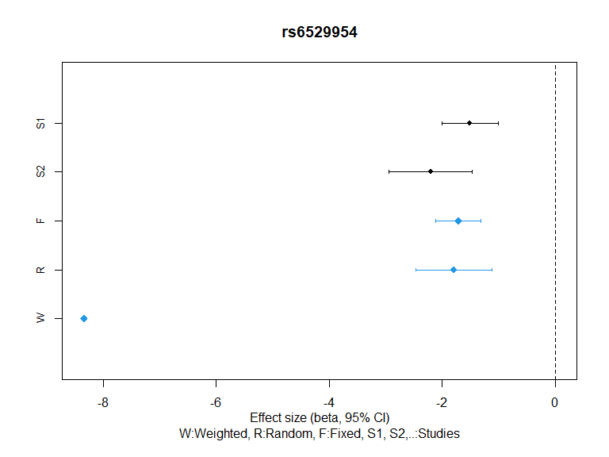

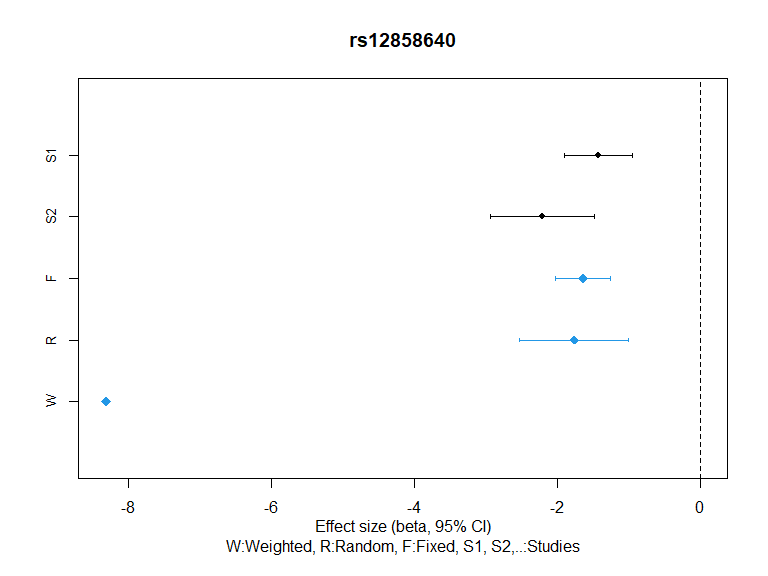

```
## [1] "Meta_Analysis.plot files containing the forest plots of the SNPs are produced in the directory C:\\Users\\Sarah\\AppData\\Local\\Temp\\RtmpucHg2F."
```

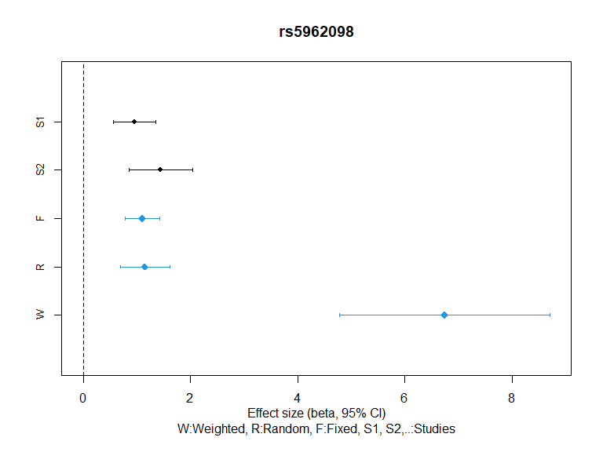

```
## [1] "Meta_Analysis.plot files containing the forest plots of the SNPs are produced in the directory C:\\Users\\Sarah\\AppData\\Local\\Temp\\RtmpucHg2F."
```

```r
DataDir = system.file("extdata", package = "GXwasR")
ResultDir = tempdir()
SummData <- list(Summary_Stat_Ex1,Summary_Stat_Ex2)
SNPfile = "UniqueLoci"
useSNPposition = FALSE
UseA1 = TRUE
GCse = TRUE
byCHR = FALSE
pval_filter = "R"
top_snp_pval = 1e-08
max_top_snps = 10
chosen_snps_file = NULL
pval_threshold_manplot = 1e-05
plotname = "Meta_Analysis.plot"

x <- MetaGWAS(DataDir = DataDir, SummData = SummData,ResultDir=ResultDir, SNPfile = NULL, useSNPposition = TRUE, UseA1 = UseA1,GCse = GCse, plotname = "Meta_Analysis.plot", pval_filter, top_snp_pval, max_top_snps, chosen_snps_file = NULL, byCHR, pval_threshold_manplot)
```

## Random effect result

```r
# Dataframe with the fixed effect result
x1 <- x$Resultrandom
x2 <- x1[order(x1$P),]
knitr::kable(x2[1:10,], caption = 'Top ten associations from random effect model.')
```

Top ten associations from random effect model.

|  | CHR | BP | SNP | A1 | A2 | Q | I | P | ES | SE | CI_L | CI_U |
| --- | --- | --- | --- | --- | --- | --- | --- | --- | --- | --- | --- | --- |
| 1054 | 23 | 4184349 | rs6529954 | A | ? | 0.1162 | 59.48 | 0.0000002 | -1.7980 | 0.3441459 | -2.4725260 | -1.1234740 |
| 1053 | 23 | 4137114 | rs5962098 | A | ? | 0.1753 | 45.56 | 0.0000010 | 1.1488 | 0.2351018 | 0.6880004 | 1.6095996 |
| 1043 | 23 | 3376304 | rs6420571 | A | ? | 0.3068 | 4.26 | 0.0000015 | -1.1667 | 0.2426946 | -1.6423814 | -0.6910186 |
| 1055 | 23 | 4214861 | rs12858640 | C | ? | 0.0725 | 69.00 | 0.0000062 | -1.7572 | 0.3887229 | -2.5190968 | -0.9953032 |
| 559 | 2 | 2579014 | rs10186455 | G | ? | 0.4490 | 0.00 | 0.0000476 | 1.2694 | 0.3121061 | 0.6576721 | 1.8811279 |
| 1052 | 23 | 4119808 | rs10521557 | A | ? | 0.8021 | 0.00 | 0.0000631 | 1.4884 | 0.3720121 | 0.7592563 | 2.2175437 |
| 6 | 1 | 1127860 | rs148527527 | G | ? | 0.5778 | 0.00 | 0.0008237 | 1.3978 | 0.4179142 | 0.5786881 | 2.2169119 |
| 558 | 2 | 2535670 | rs13430614 | C | ? | 0.6681 | 0.00 | 0.0010230 | 0.6358 | 0.1935981 | 0.2563478 | 1.0152522 |
| 1382 | 23 | 45563626 | rs1207312 | T | ? | 0.5388 | 0.00 | 0.0046670 | 0.6138 | 0.2169547 | 0.1885689 | 1.0390311 |
| 1383 | 23 | 45565805 | rs1780835 | A | ? | 0.5206 | 0.00 | 0.0064620 | 0.5404 | 0.1984308 | 0.1514757 | 0.9293243 |

## Fixed effect result

```r
# Dataframe with the fixed effect result
x1 <- x$Resultfixed
x2 <- x1[order(x1$P),]
knitr::kable(x2[1:10,], caption = 'Top ten associations from fixed effect model.')
```

Top ten associations from fixed effect model.

|  | CHR | BP | SNP | A1 | A2 | Q | I | P | ES | SE | CI_L | CI_U |
| --- | --- | --- | --- | --- | --- | --- | --- | --- | --- | --- | --- | --- |
| 1054 | 23 | 4184349 | rs6529954 | A | ? | 0.1162 | 59.48 | 0.0000000 | -1.7127 | 0.2025697 | -2.1097365 | -1.3156635 |
| 1055 | 23 | 4214861 | rs12858640 | C | ? | 0.0725 | 69.00 | 0.0000000 | -1.6364 | 0.1955735 | -2.0197240 | -1.2530760 |
| 1053 | 23 | 4137114 | rs5962098 | A | ? | 0.1753 | 45.56 | 0.0000000 | 1.1030 | 0.1618941 | 0.7856876 | 1.4203124 |
| 1043 | 23 | 3376304 | rs6420571 | A | ? | 0.3068 | 4.26 | 0.0000009 | -1.1647 | 0.2371161 | -1.6294476 | -0.6999524 |
| 559 | 2 | 2579014 | rs10186455 | G | ? | 0.4490 | 0.00 | 0.0000476 | 1.2694 | 0.3121061 | 0.6576721 | 1.8811279 |
| 1052 | 23 | 4119808 | rs10521557 | A | ? | 0.8021 | 0.00 | 0.0000631 | 1.4884 | 0.3720121 | 0.7592563 | 2.2175437 |
| 6 | 1 | 1127860 | rs148527527 | G | ? | 0.5778 | 0.00 | 0.0008237 | 1.3978 | 0.4179142 | 0.5786881 | 2.2169119 |
| 558 | 2 | 2535670 | rs13430614 | C | ? | 0.6681 | 0.00 | 0.0010230 | 0.6358 | 0.1935981 | 0.2563478 | 1.0152522 |
| 638 | 2 | 8181194 | rs7370955 | A | ? | 0.2403 | 27.48 | 0.0024130 | 0.7752 | 0.2555007 | 0.2744187 | 1.2759813 |
| 1382 | 23 | 45563626 | rs1207312 | T | ? | 0.5388 | 0.00 | 0.0046670 | 0.6138 | 0.2169547 | 0.1885689 | 1.0390311 |

## Weighted effect result

```r
# Dataframe with the fixed effect result
x1 <- x$Resultweighted
x2 <- x1[order(x1$P),]
knitr::kable(x2[1:10,], caption = 'Top ten associations from weighted effect model.')
```

Top ten associations from weighted effect model.

|  | CHR | BP | SNP | A1 | A2 | Q | I | P | ES | SE | CI_L | CI_U |
| --- | --- | --- | --- | --- | --- | --- | --- | --- | --- | --- | --- | --- |
| 1054 | 23 | 4184349 | rs6529954 | A | ? | 0.1162 | 59.48 | 0.0000000 | -8.340 | 0.0000000 | -8.3400000 | -8.340000 |
| 1055 | 23 | 4214861 | rs12858640 | C | ? | 0.0725 | 69.00 | 0.0000000 | -8.306 | 0.0000000 | -8.3060000 | -8.306000 |
| 1053 | 23 | 4137114 | rs5962098 | A | ? | 0.1753 | 45.56 | 0.0000000 | 6.741 | 1.0000820 | 4.7808392 | 8.701161 |
| 1043 | 23 | 3376304 | rs6420571 | A | ? | 0.3068 | 4.26 | 0.0000010 | -4.883 | 1.0000062 | -6.8430122 | -2.922988 |
| 559 | 2 | 2579014 | rs10186455 | G | ? | 0.4490 | 0.00 | 0.0000723 | 3.969 | 1.0000874 | 2.0088287 | 5.929171 |
| 1052 | 23 | 4119808 | rs10521557 | A | ? | 0.8021 | 0.00 | 0.0000955 | 3.902 | 1.0000837 | 1.9418359 | 5.862164 |
| 6 | 1 | 1127860 | rs148527527 | G | ? | 0.5778 | 0.00 | 0.0010750 | 3.270 | 0.9999618 | 1.3100749 | 5.229925 |
| 558 | 2 | 2535670 | rs13430614 | C | ? | 0.6681 | 0.00 | 0.0014260 | 3.189 | 0.9998946 | 1.2292065 | 5.148794 |
| 638 | 2 | 8181194 | rs7370955 | A | ? | 0.2403 | 27.48 | 0.0032420 | 2.944 | 1.0000649 | 0.9838728 | 4.904127 |
| 1382 | 23 | 45563626 | rs1207312 | T | ? | 0.5388 | 0.00 | 0.0048350 | 2.818 | 1.0000617 | 0.8578790 | 4.778121 |

## Metadata of the meta analysis

```r
# Dataframe with the metadata
x1 <- x$Metadata
x2 <- x1[order(x1$Q),]
knitr::kable(x2[1:10,], caption = 'Metadata of the top ten associations based on Cochrane’s Q statistics.')
```

Metadata of the top ten associations based on Cochrane’s Q statistics.

|  | CHR | BP | SNP | A1 | A2 | N | Q | I | F0 | F1 |
| --- | --- | --- | --- | --- | --- | --- | --- | --- | --- | --- |
| 812 | 2 | 21385538 | rs575905 | T | ? | 2 | 0.0010 | 90.73 | -0.5218 | 0.6472 |
| 1110 | 23 | 9277424 | rs2214279 | G | ? | 2 | 0.0015 | 90.09 | 0.5001 | -0.5365 |
| 655 | 2 | 9913645 | rs1106144 | A | ? | 2 | 0.0020 | 89.48 | 0.5909 | -0.8972 |
| 663 | 2 | 10210922 | rs11678624 | T | ? | 2 | 0.0021 | 89.45 | -0.3659 | 0.7374 |
| 1207 | 23 | 23909933 | rs2428144 | A | ? | 2 | 0.0031 | 88.55 | 0.5344 | -0.4081 |
| 1253 | 23 | 29189630 | rs225456 | C | ? | 2 | 0.0031 | 88.56 | 0.3208 | -1.1170 |
| 1248 | 23 | 28763567 | rs12008039 | G | ? | 2 | 0.0032 | 88.48 | -0.3187 | 0.5565 |
| 810 | 2 | 21275825 | rs12468735 | A | ? | 2 | 0.0036 | 88.19 | -0.5095 | 0.5175 |
| 664 | 2 | 10343419 | rs759347 | C | ? | 2 | 0.0041 | 87.88 | 0.9790 | -0.3894 |
| 1251 | 23 | 29104124 | rs16988439 | C | ? | 2 | 0.0042 | 87.81 | 0.3208 | -1.0730 |

## Problematic SNPs

```r
# Dataframe with the problematic SNPs
x1 <- x$ProblemSNP
knitr::kable(x1[1:10,], caption = 'Top ten probematic SNPs.')
```

Top ten probematic SNPs.

| File | SNP | Problem |
| --- | --- | --- |
| C:2F/SNPdata_2 | rs2803333 | ALLELE_MISMATCH |
| C:2F/SNPdata_2 | rs672606 | ALLELE_MISMATCH |
| C:2F/SNPdata_2 | rs7519955 | ALLELE_MISMATCH |
| C:2F/SNPdata_2 | rs1538466 | ALLELE_MISMATCH |
| C:2F/SNPdata_2 | rs61777960 | ALLELE_MISMATCH |
| C:2F/SNPdata_2 | rs2865211 | ALLELE_MISMATCH |
| C:2F/SNPdata_2 | rs10917217 | ALLELE_MISMATCH |
| C:2F/SNPdata_2 | rs196402 | ALLELE_MISMATCH |
| C:2F/SNPdata_2 | rs6662038 | ALLELE_MISMATCH |
| C:2F/SNPdata_2 | rs3845484 | ALLELE_MISMATCH |

## Including Plots

### Manhattan Plots and QQ plots:

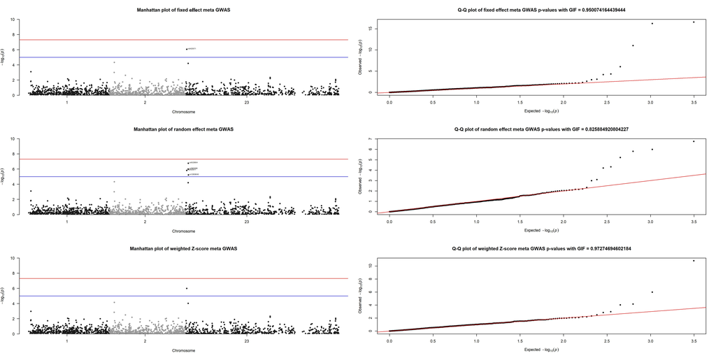

### All Forest plots

Now, let’s see all the Forest plots.

[figure not shown]

## Citation

If you are using GXwasR package and/or following this pipeline in your study, please cite it as:

```r
citation("GXwasR")
```

[output not shown]

## Tutorials Link

**Please follow these tutorials to know more about the functionality of the package GXwasR.**

A list of all the functions in GXwasR:

Tutorial for performing post-imputation QC followed by sex-aware association tests:

Tutorial for performing pre-imputation QC using GXwasR:

Tutorial for performing post-imputation QC using GXwasR:

Tutorial for ancestry estimation:

Tutorial for meta analysis:

Tutorial for heritability estimate and genetic correlation:

Tutorial for gene-based tests:

```
                              ******************* THANK YOU! *************************
```